# Datasety

## Hypotéza 2

*H0*: Hodnota erytrocyty zdravých pacientov je v priemere rovnaká ako u chorých pacientov. *HA*: Hodnota erytrocyty zdravých pacientov je v priemere vyššia/nižšia, menšie ako u chorých pacientov.

```python
healthy_erytrocyty = labor.loc[labor.indicator == 0, 'erytrocyty'].dropna()
```

```python
healthy_erytrocyty.describe()
```

```
count    3558.000000
mean        5.807875
std         1.010541
min         2.357680
25%         5.117225
50%         5.803070
75%         6.498003
max         9.559990
Name: erytrocyty, dtype: float64
```

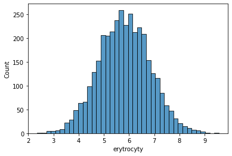

```python
sns.histplot(healthy_erytrocyty)
```

```python
healthy_erytrocyty_out = identify_outliers(healthy_erytrocyty)
healthy_erytrocyty_out
```

```
44      2.83198
256     9.55999
353     8.77578
1140    8.73768
1440    2.93465
1606    8.61541
1801    8.85864
2358    8.59704
2483    8.75396
2841    8.98971
3696    8.62926
4121    2.76214
5047    2.35768
6240    3.00306
6444    8.66575
7499    2.72305
7982    9.06617
8175    8.83662
8788    2.92640
8834    2.65822
8896    2.74850
8934    8.66328
8961    8.87136
9187    2.72877
9294    8.57463
Name: erytrocyty, dtype: float64
```

```python
healthy_erytrocyty = healthy_erytrocyty.drop(healthy_erytrocyty_out.index)
```

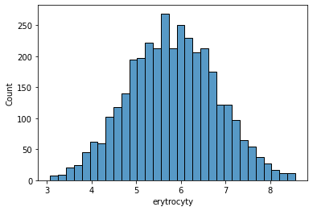

```python
sns.histplot(healthy_erytrocyty)
```

```python
test_frame = labor.sample(n=4500)
unhealthy_erytrocyty = test_frame.loc[test_frame.indicator == 1, 'erytrocyty'].dropna()
```

```python
unhealthy_erytrocyty.describe()
```

```
count    2893.000000
mean        5.780379
std         1.000213
min         1.824980
25%         5.114370
50%         5.784790
75%         6.430700
max         9.030800
Name: erytrocyty, dtype: float64
```

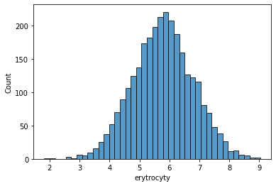

```python
sns.histplot(unhealthy_erytrocyty)
```

```python
unhealthy_erytrocyty_out = identify_outliers(unhealthy_erytrocyty)
unhealthy_erytrocyty_out
```

```
2525    2.89950
9242    2.61663
8645    3.08231
4102    3.04759
1293    1.82498
3289    9.03080
5218    2.70524
8942    2.70576
3677    3.07512
4668    8.56672
2384    8.83335
8985    2.15349
9821    8.53005
4255    8.81403
6505    3.13326
9896    3.11926
208     8.63207
8703    3.01624
8045    8.51821
64      8.45245
9721    8.58977
2300    8.41906
2522    2.99799
1872    8.97430
8855    2.93736
Name: erytrocyty, dtype: float64
```

```python
unhealthy_erytrocyty = unhealthy_erytrocyty.drop(unhealthy_erytrocyty_out.index)
```

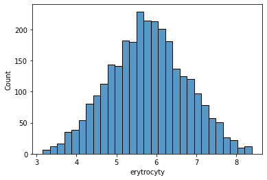

```python
sns.histplot(unhealthy_erytrocyty)
```

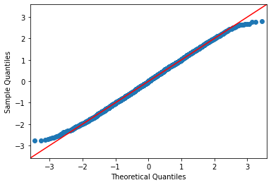

```python
_ = sm.ProbPlot(healthy_erytrocyty, fit=True).qqplot(line='45')
```

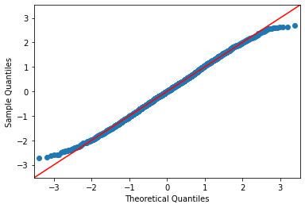

```python
_ = sm.ProbPlot(unhealthy_erytrocyty, fit=True).qqplot(line='45')
```

```python
stats.shapiro(healthy_erytrocyty)
```

```
ShapiroResult(statistic=0.9982246160507202, pvalue=0.0005400139489211142)
```

```python
stats.shapiro(unhealthy_erytrocyty)
```

```
ShapiroResult(statistic=0.997503936290741, pvalue=0.000136909366119653)
```

Podľa Shapiro-willkov testu normálnosti zamietneme nulovú hypotézu a mali by sme použiť Mann-Whitneyho test

```python
stats.levene(healthy_erytrocyty, unhealthy_erytrocyty)
```

```
LeveneResult(statistic=1.5173751168392449, pvalue=0.2180624125972769)
```

Podľa Levenovho testu vieme určiť, že vzorky zrejme pochádzajú z distribucíí s rovnakou varianciou

```python
stats.mannwhitneyu(healthy_erytrocyty, unhealthy_erytrocyty)
```

```
MannwhitneyuResult(statistic=5124153.0, pvalue=0.4315432086059158)
```

Podľa Man-Whineyuho testu sme zistili, že chyba 1.rádu je veľmi veľká a k Levenov test ukázal, že dáta pravdepodobne pochádzajú z distribúcií s rovnakou varianciou, a tak našu Nulovú hypotézu H0 nezamietame ale potvrdzujeme

```python
sms.DescrStatsW(healthy_erytrocyty).tconfint_mean()
```

```
(5.771343254452852, 5.836100838386091)
```

```python
sms.DescrStatsW(unhealthy_erytrocyty).tconfint_mean()
```

```
(5.748439460632206, 5.8191763692143805)
```

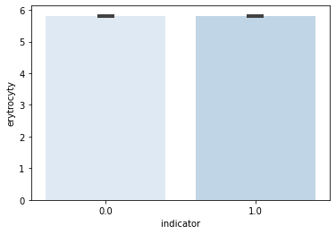

```python
sns.barplot(x='indicator', y='erytrocyty', data=labor[(labor.indicator == 1) | (labor.indicator == 0)],
            capsize=0.1, errwidth=2, palette=sns.color_palette("Blues"))
```

Aj na grafe môžeme vidieť, že hodnoty sú vcelku rovnaké

# 4. Identifikácia problémov v dátach s navrhnutým riešením

- Identifikujte problémy v dátach napr.: nevhodná štruktúra dát, duplicitné záznamy, nejednotné formáty, chýbajúce hodnoty, vychýlené hodnoty.
- V dátach sa môžu nachádzať aj iné, tu nevymenované problémy.
- Navrhnuté riešenie prvotne realizujte na dátach. Problém s dátami môžete riešiť iteratívne v každej fáze aj vo všetkých fázach podľa potreby.

```python
# Number of Na profiles
profiles.shape[0] - profiles.dropna().shape[0]
```

```
0
```

```python
# Number of Na labor
labor.shape[0] - labor.dropna().shape[0]
```

```
329
```

```python
labor.isnull().sum()
```

```
Unnamed: 0       0
etytr           30
indicator        0
alp             31
er-cv           30
leukocyty       30
hbver           30
alt             30
trombocyty      30
ast             30
weight           0
ssn              0
relationship     0
hematokrit      31
smoker           0
hemoglobin      30
erytrocyty      31
name             0
dtype: int64
```

```python
profiles.info()
```

```
<class 'pandas.core.frame.DataFrame'>
RangeIndex: 3123 entries, 0 to 3122
Data columns (total 10 columns):
 #   Column            Non-Null Count  Dtype
---  ------            --------------  -----
 0   Unnamed: 0        3123 non-null   int64
 1   blood_group       3123 non-null   object
 2   job               3123 non-null   object
 3   sex               3123 non-null   object
 4   name              3123 non-null   object
 5   company           3123 non-null   object
 6   race              3123 non-null   object
 7   ssn               3123 non-null   object
 8   birthdate         3123 non-null   object
 9   current_location  3123 non-null   object
dtypes: int64(1), object(9)
memory usage: 244.1+ KB
```

```python
labor.info()
```

```
<class 'pandas.core.frame.DataFrame'>
RangeIndex: 9976 entries, 0 to 9975
Data columns (total 18 columns):
 #   Column        Non-Null Count  Dtype
---  ------        --------------  -----
 0   Unnamed: 0    9976 non-null   int64
 1   etytr         9946 non-null   float64
 2   indicator     9976 non-null   float64
 3   alp           9945 non-null   float64
 4   er-cv         9946 non-null   float64
 5   leukocyty     9946 non-null   float64
 6   hbver         9946 non-null   float64
 7   alt           9946 non-null   float64
 8   trombocyty    9946 non-null   float64
 9   ast           9946 non-null   float64
 10  weight        9976 non-null   float64
 11  ssn           9976 non-null   object
 12  relationship  9976 non-null   object
 13  hematokrit    9945 non-null   float64
 14  smoker        9976 non-null   object
 15  hemoglobin    9946 non-null   float64
 16  erytrocyty    9945 non-null   float64
 17  name          9976 non-null   object
dtypes: float64(13), int64(1), object(4)
memory usage: 1.4+ MB
```

```python
# List all rows containing null values
labor[labor.isnull().any(axis=1)]
```

|  | Unnamed: 0 | etytr | indicator | alp | er-cv | leukocyty | hbver | alt | trombocyty | ast | weight | ssn | relationship | hematokrit | smoker | hemoglobin | erytrocyty | name |
| --- | --- | --- | --- | --- | --- | --- | --- | --- | --- | --- | --- | --- | --- | --- | --- | --- | --- | --- |
| 24 | 24 | 4.67870 | 0.0 | 40.61720 | 65.84055 | 4.81551 | 5.58746 | 4.68397 | NaN | 74.83465 | 113.12785 | 409-43-1283 | divoced | 6.09808 | no | 8.20259 | 4.17508 | James Daniel |
| 84 | 84 | NaN | 1.0 | 72.97158 | 40.64987 | 7.14212 | 6.02901 | 9.94711 | 7.47247 | 66.42493 | 86.01786 | 011-38-1168 | married | 4.39631 | no | 7.18545 | 4.14178 | Meghan Garner |
| 94 | 94 | 4.01809 | 1.0 | 32.26899 | 61.97734 | 5.68369 | 9.17297 | 13.87185 | 3.74418 | 72.40242 | 86.72634 | 409-43-1283 | nop | 5.83529 | yes | 4.09266 | NaN | James Daniel |
| 124 | 124 | 5.14318 | 0.0 | 80.12452 | 41.39639 | NaN | 6.83925 | 8.44584 | 4.68128 | 67.34317 | 35.53901 | 305-18-3975 | separated | 5.57690 | yes | 7.07607 | 4.59136 | Mary Carpenter |
| 208 | 208 | 5.24823 | 1.0 | 24.92220 | 30.79911 | 3.93760 | 6.47111 | 33.04987 | 8.46589 | NaN | 36.74598 | 037-76-4977 | divoced | 5.31014 | yes | 4.14145 | 8.63207 | Regina Franklin |
| ... | ... | ... | ... | ... | ... | ... | ... | ... | ... | ... | ... | ... | ... | ... | ... | ... | ... | ... |
| 9844 | 9844 | 5.78776 | 1.0 | 29.98515 | 71.16022 | 5.96796 | 7.64652 | 11.39465 | NaN | 50.24104 | 96.19817 | 748-70-9973 | widowed | 7.05456 | yes | 4.16839 | 5.83897 | Holly Williams |
| 9881 | 9881 | 5.88557 | 1.0 | 29.14889 | 36.05389 | 4.27246 | 6.55006 | 6.60883 | 8.14150 | 63.95205 | 86.46901 | 779-61-1579 | separated | 4.11969 | Y | 3.98632 | NaN | Cathy Dean |
| 9888 | 9888 | NaN | 1.0 | 58.21868 | 42.68911 | 4.14231 | 7.90606 | 6.88902 | 5.64783 | 80.65205 | 111.07323 | 548-78-1335 | divoced | 5.82836 | no | 4.76667 | 6.42993 | Christopher Cortez |
| 9908 | 9908 | 5.03432 | 0.0 | 90.70412 | 52.55536 | NaN | 7.08549 | 5.04675 | 3.80445 | 78.18837 | 40.77415 | 366-67-6100 | single | 5.30154 | no | 5.94084 | 4.93684 | Alexandria Knapp |
| 9914 | 9914 | 5.85724 | 1.0 | 80.79200 | 42.97881 | 6.84304 | 7.68211 | 7.73992 | 4.70194 | 71.71232 | 59.84489 | 473-66-9129 | married | 5.98232 | yes | NaN | 5.37009 | Andrew Carpenter |

329 rows × 18 columns

```python
#save data to file
#df.to_csv('dataset/<filename>.tsv', sep='\t', index=False, encoding='utf-8')
```

```python
labor = labor.rename(columns={'Unnamed: 0':'id_labor'})
labor.set_index('id_labor')
```

| id_labor | etytr | indicator | alp | er-cv | leukocyty | hbver | alt | trombocyty | ast | weight | ssn | relationship | hematokrit | smoker | hemoglobin | erytrocyty | name |
| --- | --- | --- | --- | --- | --- | --- | --- | --- | --- | --- | --- | --- | --- | --- | --- | --- | --- |
| 0 | 6.56611 | 0.0 | 71.34866 | 49.93293 | 4.01096 | 7.63611 | 16.53642 | 4.12686 | 62.82161 | 38.94182 | 613-31-7943 | married | 6.15761 | no | 7.24929 | 7.40249 | Terry Walker |
| 1 | 6.57510 | 0.0 | 73.19819 | 50.61146 | 7.36386 | 4.45735 | 12.41316 | 6.89853 | 64.10856 | 39.93677 | 071-29-7068 | widowed | 5.02794 | no | 7.41189 | 7.05999 | Christopher Mccall |
| 2 | 7.46203 | 1.0 | 12.80221 | 45.76702 | 7.86319 | 6.46036 | 7.75601 | 6.02906 | 62.88964 | 36.82128 | 465-01-6369 | married | 4.67262 | Y | 9.91113 | 5.59064 | Mrs. Alisha Jackson DVM |
| 3 | 5.15667 | 1.0 | 86.69531 | 41.73339 | 4.49672 | 3.99015 | 3.84333 | 6.71704 | 72.09725 | 64.70210 | 698-87-9617 | single | 6.40977 | Y | 6.55248 | 5.71480 | Crystal Dean |
| 4 | 4.25219 | 1.0 | 11.50857 | 43.33880 | 3.68340 | 8.19481 | 6.28617 | 6.51026 | 66.57561 | -3.98413 | 209-04-2399 | separated | 5.65006 | no | 3.15066 | 5.61537 | Joseph Garza |
| ... | ... | ... | ... | ... | ... | ... | ... | ... | ... | ... | ... | ... | ... | ... | ... | ... | ... |
| 9971 | 4.92591 | 0.0 | 22.84636 | 47.26370 | 2.48835 | 6.95191 | 24.40903 | 6.90815 | 70.22225 | 8.04015 | 124-16-4553 | widowed | 6.28803 | no | 8.70110 | 8.30753 | Danny Williams |
| 9972 | 5.88588 | 0.0 | 77.34828 | 75.18520 | 4.28394 | 5.78731 | 8.08100 | 5.32133 | 75.46584 | 87.02870 | 801-46-6436 | widowed | 4.70667 | yes | 5.27741 | 6.64176 | Kimberly Burch |
| 9973 | 5.94623 | 1.0 | 73.75165 | 37.08749 | 6.45990 | 4.82462 | 5.78515 | 6.80749 | 62.35952 | 28.06520 | 103-41-5796 | married | 4.71323 | no | 7.43538 | 5.87397 | Wayne Norman |
| 9974 | 8.17323 | 1.0 | 29.59053 | 67.02969 | 7.39854 | 4.02898 | 4.71975 | 8.46820 | 80.36628 | 86.51719 | 170-29-9438 | separated | 5.35195 | N | 4.25246 | 5.65523 | Kristin Wong |
| 9975 | 5.81134 | 1.0 | 83.60103 | 43.37931 | 4.93679 | 7.26814 | 4.82618 | 5.71348 | 68.34664 | 36.88248 | 647-95-3824 | single | 5.45397 | yes | 5.58794 | 4.60036 | Cynthia Zimmerman |

9976 rows × 17 columns

```python
# Weight is below 0
labor[labor['weight'] < 0]
```

|  | id_labor | etytr | indicator | alp | er-cv | leukocyty | hbver | alt | trombocyty | ast | weight | ssn | relationship | hematokrit | smoker | hemoglobin | erytrocyty | name |
| --- | --- | --- | --- | --- | --- | --- | --- | --- | --- | --- | --- | --- | --- | --- | --- | --- | --- | --- |
| 4 | 4 | 4.25219 | 1.0 | 11.50857 | 43.33880 | 3.68340 | 8.19481 | 6.28617 | 6.51026 | 66.57561 | -3.98413 | 209-04-2399 | separated | 5.65006 | no | 3.15066 | 5.61537 | Joseph Garza |
| 12 | 12 | 7.45985 | 0.0 | 44.89612 | 71.06880 | 2.82551 | 4.25394 | 8.92940 | 8.18667 | 69.71307 | -7.45880 | 057-52-4512 | divoced | 5.21050 | yes | 8.09933 | 6.40121 | Donna Acosta |
| 47 | 47 | 5.76418 | 0.0 | 83.77569 | 37.34492 | 4.86190 | 5.03589 | 11.24835 | 6.41601 | 72.85593 | -10.98075 | 280-99-3868 | widowed | 5.46548 | no | 5.65429 | 4.78133 | Christina Harris |
| 66 | 66 | 7.40217 | 1.0 | 15.34635 | 52.40322 | 4.49002 | 9.83963 | 13.33373 | 3.73180 | 64.56452 | -20.43153 | 191-13-3353 | divoced | 6.58267 | no | 3.17575 | 7.52013 | Casey Harris |
| 197 | 197 | 5.07686 | 0.0 | 84.97279 | 43.97857 | 3.98114 | 7.14523 | 7.49582 | 4.57366 | 74.14419 | -5.83706 | 744-63-3326 | married | 3.98797 | N | 6.94458 | 6.50220 | Lisa Santana |
| ... | ... | ... | ... | ... | ... | ... | ... | ... | ... | ... | ... | ... | ... | ... | ... | ... | ... | ... |
| 9868 | 9868 | 3.79981 | 0.0 | 34.62625 | 56.27918 | 3.75853 | 8.46265 | 6.43348 | 3.57446 | 80.12457 | -0.75156 | 148-05-5204 | nop | 7.43917 | yes | 8.20493 | 5.66157 | Kimberly Oneal |
| 9876 | 9876 | 6.07822 | 1.0 | 78.91486 | 57.24705 | 7.08122 | 3.89736 | 9.86064 | 7.58186 | 85.47576 | -3.04102 | 334-01-9397 | nop | 6.77781 | yes | 5.62884 | 4.09318 | Timothy Miller |
| 9882 | 9882 | 6.65452 | 0.0 | 23.74081 | 63.90448 | 5.79564 | 8.73818 | 8.34635 | 2.72969 | 70.85690 | -10.42991 | 466-65-7754 | single | 5.50550 | yes | 8.57765 | 6.33862 | Ralph Chen |
| 9897 | 9897 | 7.08630 | 0.0 | 67.54793 | 63.45475 | 4.56532 | 4.25441 | 10.10955 | 7.22103 | 70.47193 | -8.55406 | 877-59-5554 | single | 6.77324 | no | 7.46819 | 3.84360 | Stephanie Estrada |
| 9939 | 9939 | 5.15318 | 0.0 | 62.71391 | 36.07544 | 3.06897 | 7.38783 | 4.53295 | 4.90833 | 65.16317 | -7.43724 | 193-13-2524 | divoced | 6.04519 | N | 7.63286 | 6.66544 | Tristan Stewart |

220 rows × 18 columns

```
array([[<AxesSubplot:title={'center':'weight'}>]], dtype=object)
```

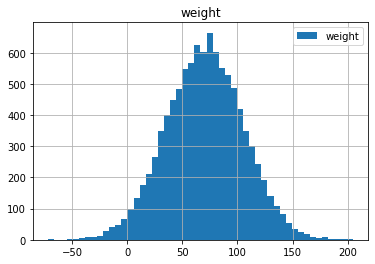

```python
labor.hist(column='weight', legend=1, bins=50)
```

```
array([[<AxesSubplot:title={'center':'weight'}>]], dtype=object)
```

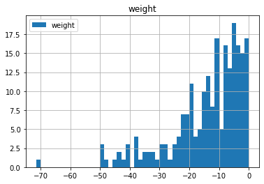

```python
labor[labor['weight'] <= 0].hist(column='weight', legend=1, bins=50)
```

```python
len(labor[labor['weight'] <= 0])
```

```
220
```

```python
#convert to date
profiles.birthdate = pd.to_datetime(profiles.birthdate)
```

```python
profiles = profiles.rename(columns={'Unnamed: 0':'id_profiles'})
profiles.set_index('id_profiles')
```

| id_profiles | blood_group | job | sex | name | company | race | ssn | birthdate | current_location |
| --- | --- | --- | --- | --- | --- | --- | --- | --- | --- |
| 0 | A- | Pension scheme manager | F | Megan Wells | Smith-Lawrence | Indian | 788-45-8299 | 1913-08-15 | (Decimal('-2.7462585'), Decimal('-56.259761')) |
| 1 | AB+ | Psychotherapist, child | F | Barbara Patel | Oneal and Sons | Hawaiian | 291-49-5180 | 1905-10-29 | (Decimal('-54.1724985'), Decimal('163.273340')) |
| 2 | B- | Engineer, drilling | F | Brianna Lane | Morris-Arnold | Asian | 146-49-1796 | 1980-05-13 | (Decimal('39.8342665'), Decimal('-54.720127')) |
| 3 | A- | Engineer, mining | M | William Cooper | Dunn LLC | White | 700-73-0733 | 1921-12-14 | (Decimal('-76.8352515'), Decimal('-0.539735')) |
| 4 | A+ | Restaurant manager | F | Holly Williams | Bailey-Sullivan | White | 748-70-9973 | 1924-12-30 | (Decimal('-59.667122'), Decimal('81.468274')) |
| ... | ... | ... | ... | ... | ... | ... | ... | ... | ... |
| 3118 | AB+ | Hotel manager | F | Wendy Hopkins | Edwards, Hicks and Brown | White | 093-80-1903 | 2010-10-29 | (Decimal('-51.369791'), Decimal('169.810393')) |
| 3119 | B+ | Learning disability nurse | M | Jason Harris | Villanueva Inc | Asian | 455-15-7740 | 1939-10-02 | (Decimal('0.2157865'), Decimal('2.399022')) |
| 3120 | B- | Early years teacher | F | Carolyn Roberson | Gomez-Salas | White | 857-79-0008 | 2002-11-21 | (Decimal('-31.7996455'), Decimal('-159.330298')) |
| 3121 | B- | Producer, television/film/video | F | Amber Shah | Mclaughlin and Sons | White | 371-91-5490 | 2009-03-11 | (Decimal('9.0348495'), Decimal('-133.498036')) |
| 3122 | A- | Tour manager | F | Laura Smith | Chan-Ellis | Indian | 524-13-3562 | 1929-01-29 | (Decimal('19.2334285'), Decimal('4.346473')) |

3123 rows × 9 columns

```python
profiles.groupby('race').count()
```

| race | id_profiles | blood_group | job | sex | name | company | ssn | birthdate | current_location |
| --- | --- | --- | --- | --- | --- | --- | --- | --- | --- |
| Asian | 333 | 333 | 333 | 333 | 333 | 333 | 333 | 333 | 333 |
| Black | 751 | 751 | 751 | 751 | 751 | 751 | 751 | 751 | 751 |
| Hawaiian | 148 | 148 | 148 | 148 | 148 | 148 | 148 | 148 | 148 |
| Indian | 149 | 149 | 149 | 149 | 149 | 149 | 149 | 149 | 149 |
| White | 1559 | 1559 | 1559 | 1559 | 1559 | 1559 | 1559 | 1559 | 1559 |
| black | 121 | 121 | 121 | 121 | 121 | 121 | 121 | 121 | 121 |
| blsck | 32 | 32 | 32 | 32 | 32 | 32 | 32 | 32 | 32 |
| white | 30 | 30 | 30 | 30 | 30 | 30 | 30 | 30 | 30 |

```python
# Replace typos in race
profiles['race'].replace({'blsck':'Black', 'black':'Black', 'white':'White'}, inplace=True)
```

```python
profiles.groupby('race').count().iloc[:,0]
```

```
race
Asian        333
Black        904
Hawaiian     148
Indian       149
White       1589
Name: id_profiles, dtype: int64
```

```python
labor.groupby('smoker').count()
```

| smoker | id_labor | etytr | indicator | alp | er-cv | leukocyty | hbver | alt | trombocyty | ast | weight | ssn | relationship | hematokrit | hemoglobin | erytrocyty | name |
| --- | --- | --- | --- | --- | --- | --- | --- | --- | --- | --- | --- | --- | --- | --- | --- | --- | --- |
| N | 472 | 469 | 472 | 471 | 472 | 470 | 470 | 471 | 468 | 470 | 472 | 472 | 472 | 471 | 470 | 469 | 472 |
| Y | 2012 | 2010 | 2012 | 2006 | 2007 | 2006 | 2005 | 2008 | 2006 | 2009 | 2012 | 2012 | 2012 | 2005 | 2005 | 2006 | 2012 |
| no | 5456 | 5438 | 5456 | 5436 | 5441 | 5441 | 5444 | 5437 | 5446 | 5438 | 5456 | 5456 | 5456 | 5439 | 5441 | 5441 | 5456 |
| yes | 2036 | 2029 | 2036 | 2032 | 2026 | 2029 | 2027 | 2030 | 2026 | 2029 | 2036 | 2036 | 2036 | 2030 | 2030 | 2029 | 2036 |

```python
# normalize smoker answers for binary attributes
labor['smoker'].replace({'N':0, 'Y':1, 'no':0, 'yes':0}, inplace=True)
```

```python
labor.groupby('smoker').count()
```

| smoker | id_labor | etytr | indicator | alp | er-cv | leukocyty | hbver | alt | trombocyty | ast | weight | ssn | relationship | hematokrit | hemoglobin | erytrocyty | name |
| --- | --- | --- | --- | --- | --- | --- | --- | --- | --- | --- | --- | --- | --- | --- | --- | --- | --- |
| 0 | 7964 | 7936 | 7964 | 7939 | 7939 | 7940 | 7941 | 7938 | 7940 | 7937 | 7964 | 7964 | 7964 | 7940 | 7941 | 7939 | 7964 |
| 1 | 2012 | 2010 | 2012 | 2006 | 2007 | 2006 | 2005 | 2008 | 2006 | 2009 | 2012 | 2012 | 2012 | 2005 | 2005 | 2006 | 2012 |

```python
labor.groupby('relationship').count()
```

| relationship | id_labor | etytr | indicator | alp | er-cv | leukocyty | hbver | alt | trombocyty | ast | weight | ssn | hematokrit | smoker | hemoglobin | erytrocyty | name |
| --- | --- | --- | --- | --- | --- | --- | --- | --- | --- | --- | --- | --- | --- | --- | --- | --- | --- |
| divoced | 2561 | 2556 | 2561 | 2555 | 2555 | 2555 | 2554 | 2554 | 2556 | 2555 | 2561 | 2561 | 2553 | 2561 | 2553 | 2551 | 2561 |
| married | 2554 | 2542 | 2554 | 2552 | 2545 | 2546 | 2543 | 2548 | 2542 | 2544 | 2554 | 2554 | 2545 | 2554 | 2544 | 2549 | 2554 |
| nop | 964 | 959 | 964 | 960 | 960 | 960 | 963 | 961 | 963 | 960 | 964 | 964 | 961 | 964 | 962 | 961 | 964 |
| separated | 1008 | 1004 | 1008 | 1004 | 1005 | 1003 | 1004 | 1004 | 1007 | 1006 | 1008 | 1008 | 1006 | 1008 | 1005 | 1004 | 1008 |
| single | 1904 | 1902 | 1904 | 1894 | 1899 | 1897 | 1901 | 1895 | 1897 | 1900 | 1904 | 1904 | 1899 | 1904 | 1898 | 1898 | 1904 |
| widowed | 985 | 983 | 985 | 980 | 982 | 985 | 981 | 984 | 981 | 981 | 985 | 985 | 981 | 985 | 984 | 982 | 985 |

```python
labor['relationship'].replace({'divoced':'divorced'})
```

```
0         married
1         widowed
2         married
3          single
4       separated
          ...
9971      widowed
9972      widowed
9973      married
9974    separated
9975       single
Name: relationship, Length: 9976, dtype: object
```

```python
profiles.groupby('blood_group').count()
```

| blood_group | id_profiles | job | sex | name | company | race | ssn | birthdate | current_location |
| --- | --- | --- | --- | --- | --- | --- | --- | --- | --- |
| A+ | 380 | 380 | 380 | 380 | 380 | 380 | 380 | 380 | 380 |
| A- | 362 | 362 | 362 | 362 | 362 | 362 | 362 | 362 | 362 |
| AB+ | 368 | 368 | 368 | 368 | 368 | 368 | 368 | 368 | 368 |
| AB- | 405 | 405 | 405 | 405 | 405 | 405 | 405 | 405 | 405 |
| B+ | 420 | 420 | 420 | 420 | 420 | 420 | 420 | 420 | 420 |
| B- | 387 | 387 | 387 | 387 | 387 | 387 | 387 | 387 | 387 |
| O+ | 413 | 413 | 413 | 413 | 413 | 413 | 413 | 413 | 413 |
| O- | 388 | 388 | 388 | 388 | 388 | 388 | 388 | 388 | 388 |

```python
profiles.groupby('job').count()
```

| job | id_profiles | blood_group | sex | name | company | race | ssn | birthdate | current_location |
| --- | --- | --- | --- | --- | --- | --- | --- | --- | --- |
| Academic librarian | 7 | 7 | 7 | 7 | 7 | 7 | 7 | 7 | 7 |
| Accommodation manager | 8 | 8 | 8 | 8 | 8 | 8 | 8 | 8 | 8 |
| Accountant, chartered | 4 | 4 | 4 | 4 | 4 | 4 | 4 | 4 | 4 |
| Accountant, chartered certified | 6 | 6 | 6 | 6 | 6 | 6 | 6 | 6 | 6 |
| Accountant, chartered management | 3 | 3 | 3 | 3 | 3 | 3 | 3 | 3 | 3 |
| ... | ... | ... | ... | ... | ... | ... | ... | ... | ... |
| Water quality scientist | 5 | 5 | 5 | 5 | 5 | 5 | 5 | 5 | 5 |
| Web designer | 5 | 5 | 5 | 5 | 5 | 5 | 5 | 5 | 5 |
| Wellsite geologist | 6 | 6 | 6 | 6 | 6 | 6 | 6 | 6 | 6 |
| Writer | 4 | 4 | 4 | 4 | 4 | 4 | 4 | 4 | 4 |
| Youth worker | 4 | 4 | 4 | 4 | 4 | 4 | 4 | 4 | 4 |

632 rows × 9 columns

```python
profiles.groupby('sex').count()
```

| sex | id_profiles | blood_group | job | name | company | race | ssn | birthdate | current_location |
| --- | --- | --- | --- | --- | --- | --- | --- | --- | --- |
| F | 1557 | 1557 | 1557 | 1557 | 1557 | 1557 | 1557 | 1557 | 1557 |
| M | 1566 | 1566 | 1566 | 1566 | 1566 | 1566 | 1566 | 1566 | 1566 |

```python
records = pd.merge(labor, profiles, left_on='ssn', right_on='ssn', how='left')
```

```python
records.head()
```

|  | id_labor | etytr | indicator | alp | er-cv | leukocyty | hbver | alt | trombocyty | ast | ... | name_x | id_profiles | blood_group | job | sex | name_y | company | race | birthdate | current_location |
| --- | --- | --- | --- | --- | --- | --- | --- | --- | --- | --- | --- | --- | --- | --- | --- | --- | --- | --- | --- | --- | --- |
| 0 | 0 | 6.56611 | 0.0 | 71.34866 | 49.93293 | 4.01096 | 7.63611 | 16.53642 | 4.12686 | 62.82161 | ... | Terry Walker | 1435 | AB+ | Production assistant, radio | M | Terry Walker | Kirk-Gonzalez | White | 1964-07-02 | (Decimal('-9.192940'), Decimal('-173.514920')) |
| 1 | 1 | 6.57510 | 0.0 | 73.19819 | 50.61146 | 7.36386 | 4.45735 | 12.41316 | 6.89853 | 64.10856 | ... | Christopher Mccall | 1135 | O- | Operational researcher | M | Christopher Mccall | Flowers Ltd | Black | 1957-08-15 | (Decimal('-43.635797'), Decimal('-37.672562')) |
| 2 | 2 | 7.46203 | 1.0 | 12.80221 | 45.76702 | 7.86319 | 6.46036 | 7.75601 | 6.02906 | 62.88964 | ... | Mrs. Alisha Jackson DVM | 1416 | AB- | Make | F | Mrs. Alisha Jackson DVM | Fry-Merritt | Black | 1918-06-27 | (Decimal('69.9382935'), Decimal('70.102282')) |
| 3 | 3 | 5.15667 | 1.0 | 86.69531 | 41.73339 | 4.49672 | 3.99015 | 3.84333 | 6.71704 | 72.09725 | ... | Crystal Dean | 280 | B+ | Chemist, analytical | F | Crystal Dean | May LLC | White | 1985-11-01 | (Decimal('-69.2759755'), Decimal('-101.274722')) |
| 4 | 4 | 4.25219 | 1.0 | 11.50857 | 43.33880 | 3.68340 | 8.19481 | 6.28617 | 6.51026 | 66.57561 | ... | Joseph Garza | 1979 | B- | Geophysicist/field seismologist | M | Joseph Garza | Collins Ltd | White | 2006-10-30 | (Decimal('-26.0513665'), Decimal('151.151100')) |

5 rows × 27 columns

```python
def calculate_age(born):
    today = date.today()
    return today.year - born.year - ((today.month, today.day) < (born.month, born.day))
```

```python
records['age'] = records['birthdate'].apply(calculate_age)
profiles['age'] = profiles['birthdate'].apply(calculate_age)
```

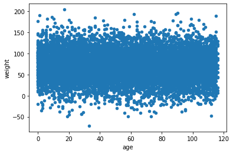

```python
records.plot.scatter(x='age', y='weight')
```

Z grafu je očividná nezrovnalosť a nesprávnosť niektorých údajov ako váha menšia ako nula alebo u novo narodených jedincov maximálna váha. Údaje by sa dali upraviť na základne priemernej závislosti medzi vekom a váhou z externého zdroja.

# Fáza 2

Realizácia predspracovania dát z datasetov zo zadania

```python
from numpy import asarray
from sklearn.model_selection import train_test_split
from sklearn.preprocessing import MinMaxScaler
from sklearn.preprocessing import StandardScaler
from sklearn.linear_model import LogisticRegression
from sklearn.feature_selection import SelectFromModel
from sklearn.feature_selection import SelectKBest
from sklearn.feature_selection import mutual_info_regression
from sklearn.feature_selection import chi2
from sklearn.feature_selection import f_regression
from sklearn.feature_selection import f_classif
```

Počet záznamov profiles dateframe-u

```python
profiles.head()
len(profiles)
```

```
3123
```

Počet záznamov records dataframe-u

```python
records.head()
len(records)
```

```
9976
```

Počet záznamov výsledného datasetu zo spájania medzi profiles a record s left join-om na profiles podľa stĺpca SSN

```python
len(records)
```

```
9976
```

Počet chýbajúcich hodnôt pre jednotlivé stĺpce dokazuje to ze spájanie datasetov prebehlo správne a chýbajúce hodnoty sú len číselné ktoré boli aj pred spájanim v datasete records

```python
records.isna().sum()
```

```
id_labor             0
etytr               30
indicator            0
alp                 31
er-cv               30
leukocyty           30
hbver               30
alt                 30
trombocyty          30
ast                 30
weight               0
ssn                  0
relationship         0
hematokrit          31
smoker               0
hemoglobin          30
erytrocyty          31
name_x               0
id_profiles          0
blood_group          0
job                  0
sex                  0
name_y               0
company              0
race                 0
birthdate            0
current_location     0
age                  0
dtype: int64
```

```python
records
```

|  | id_labor | etytr | indicator | alp | er-cv | leukocyty | hbver | alt | trombocyty | ast | ... | id_profiles | blood_group | job | sex | name_y | company | race | birthdate | current_location | age |
| --- | --- | --- | --- | --- | --- | --- | --- | --- | --- | --- | --- | --- | --- | --- | --- | --- | --- | --- | --- | --- | --- |
| 0 | 0 | 6.56611 | 0.0 | 71.34866 | 49.93293 | 4.01096 | 7.63611 | 16.53642 | 4.12686 | 62.82161 | ... | 1435 | AB+ | Production assistant, radio | M | Terry Walker | Kirk-Gonzalez | White | 1964-07-02 | (Decimal('-9.192940'), Decimal('-173.514920')) | 57 |
| 1 | 1 | 6.57510 | 0.0 | 73.19819 | 50.61146 | 7.36386 | 4.45735 | 12.41316 | 6.89853 | 64.10856 | ... | 1135 | O- | Operational researcher | M | Christopher Mccall | Flowers Ltd | Black | 1957-08-15 | (Decimal('-43.635797'), Decimal('-37.672562')) | 64 |
| 2 | 2 | 7.46203 | 1.0 | 12.80221 | 45.76702 | 7.86319 | 6.46036 | 7.75601 | 6.02906 | 62.88964 | ... | 1416 | AB- | Make | F | Mrs. Alisha Jackson DVM | Fry-Merritt | Black | 1918-06-27 | (Decimal('69.9382935'), Decimal('70.102282')) | 103 |
| 3 | 3 | 5.15667 | 1.0 | 86.69531 | 41.73339 | 4.49672 | 3.99015 | 3.84333 | 6.71704 | 72.09725 | ... | 280 | B+ | Chemist, analytical | F | Crystal Dean | May LLC | White | 1985-11-01 | (Decimal('-69.2759755'), Decimal('-101.274722')) | 36 |
| 4 | 4 | 4.25219 | 1.0 | 11.50857 | 43.33880 | 3.68340 | 8.19481 | 6.28617 | 6.51026 | 66.57561 | ... | 1979 | B- | Geophysicist/field seismologist | M | Joseph Garza | Collins Ltd | White | 2006-10-30 | (Decimal('-26.0513665'), Decimal('151.151100')) | 15 |
| ... | ... | ... | ... | ... | ... | ... | ... | ... | ... | ... | ... | ... | ... | ... | ... | ... | ... | ... | ... | ... | ... |
| 9971 | 9971 | 4.92591 | 0.0 | 22.84636 | 47.26370 | 2.48835 | 6.95191 | 24.40903 | 6.90815 | 70.22225 | ... | 141 | B+ | Civil engineer, contracting | M | Danny Williams | Holland, Jordan and Bishop | White | 1982-12-15 | (Decimal('50.052664'), Decimal('71.219050')) | 38 |
| 9972 | 9972 | 5.88588 | 0.0 | 77.34828 | 75.18520 | 4.28394 | 5.78731 | 8.08100 | 5.32133 | 75.46584 | ... | 3016 | A+ | Meteorologist | F | Kimberly Burch | Proctor, Blake and Martin | Asian | 1993-11-09 | (Decimal('89.8791105'), Decimal('118.000254')) | 28 |
| 9973 | 9973 | 5.94623 | 1.0 | 73.75165 | 37.08749 | 6.45990 | 4.82462 | 5.78515 | 6.80749 | 62.35952 | ... | 2673 | AB+ | Engineering geologist | M | Wayne Norman | Petty-Porter | White | 1923-02-04 | (Decimal('-67.3676715'), Decimal('171.062865')) | 98 |
| 9974 | 9974 | 8.17323 | 1.0 | 29.59053 | 67.02969 | 7.39854 | 4.02898 | 4.71975 | 8.46820 | 80.36628 | ... | 1577 | A+ | Manufacturing engineer | F | Kristin Wong | Bowen Ltd | White | 1907-01-08 | (Decimal('-14.3822235'), Decimal('-166.408575')) | 114 |
| 9975 | 9975 | 5.81134 | 1.0 | 83.60103 | 43.37931 | 4.93679 | 7.26814 | 4.82618 | 5.71348 | 68.34664 | ... | 1904 | B- | Ophthalmologist | F | Cynthia Zimmerman | Adkins LLC | Black | 1969-01-02 | (Decimal('-63.209551'), Decimal('130.215275')) | 52 |

9976 rows × 28 columns

```python
def drop_cols(df):
    df.set_index('ssn', inplace=True)
    return df.drop(['id_labor', 'id_profiles', 'relationship', 'birthdate', 'company', 'name_y', 'job', 'name_x', 'current_location'], axis=1, inplace=True, errors='ignore')
```

```python
drop_cols(records)
```

Odstranenie vychylenych hodnôt

```python
def identify_outliers(a):
    lower = a.quantile(0.25) - 1.5 * stats.iqr(a)
    upper = a.quantile(0.75) + 1.5 * stats.iqr(a)
    return a[(a > upper) | (a < lower)]


def remove_outliers(df):
    cols = ['etytr', 'alp', 'er-cv', 'leukocyty', 'weight' , 'age', 'erytrocyty', 'hemoglobin', 'hematokrit', 'testcol']
    for col in cols:

        try:
            temp = df[col].dropna()
        except KeyError:
            pass
        out = identify_outliers(temp)
        print('In column ' + col + ' outliers found: ' + str(len(out)))
        df.drop(out.index, inplace=True, errors='ignore')
```

```python
remove_outliers(records)
```

```
In column etytr outliers found: 66
In column alp outliers found: 0
In column er-cv outliers found: 66
In column leukocyty outliers found: 43
In column weight outliers found: 63
In column age outliers found: 0
In column erytrocyty outliers found: 78
In column hemoglobin outliers found: 15
In column hematokrit outliers found: 70
In column testcol outliers found: 70
```